# Examen Final - 1a Part

Xarxes Socials i Econòmiques

Maria del Mar Bibiloni Femenias

### Exercice 1

**1)** (**2 points**) *Do Exercise 7 in Chapter 3 (pages 95–97) in Easley-Kleinberg’s “Networks, Crowds, and Markets” (you have a copy of the book in the course’s Virtual Classroom).*

Considerem el graf de la figura següent .

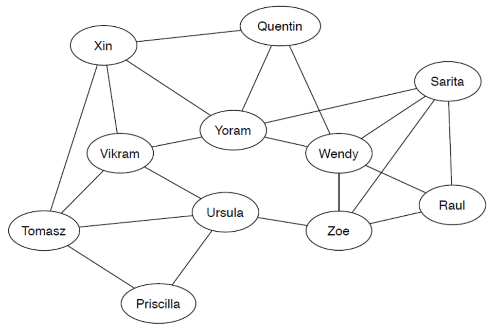

L’objectiu és que Vikram convenci a Zoe amb la idea dels programadors de fer un regal. Així, plantegen dues estratègies.

- **Programador Jove:** Vikram - Úrsula - zoe.
- **Programador major:** Vikram - Yoram - Wendy - Zoe.

El programador Jove es basa en què és el camí més curt per arribar a Zoe, i el major en la intuïció. La clau, però, no està en la longitud del camí, sinó amb la influència que pot arribar exercir Úrsula o Wendy sobre Zoe, i Vikram - Úrsula - zoe és una cua dèbil.

En el nostre graf, no tenim informació sobre els nivells d’influència, però vegem un exemple que il·lustri aquest fet. Suposem que $q=0.5$ és la proporció de veïns que necessita un node per adoptar una nova idea, en el nostre cas, la idea del regal.

- *Vikram - Úrsula - zoe*.

**Pas 0.** Vikram i Úrsula estan convençuts.  
**Pas 1**. Priscila i Tomasz també adopten la idea, ja Priscila té grau 2 i està connectada amb Úrsula, i Tomaz té grau 4 i està connectat amb Vikram i Úrsula.  
**Pas 2**. Xin té grau 4 i està connectat amb Vikram i Tomasz, aleshores està d’acord amb la idea.

Ningú més adopta la idea, ja que no arriba a tenir el $50\%$ de veïns amb ella.

- *Vikram - Yoram - Wendy - Zoe*.

Així, en tres passos s’arriba a influenciar a Zoe perquè accepti la idea del regal.

Segons l’exemple, sí seria convenient fer cas al programador gran, ja que si Zoe no es convenç a la primera, el camí per Wendy li arribaria fent acceptar la idea.

### Exercice 2

**2)** (**2 points**) *Let V be a partition of an undirected graph $G$. For every community $X_r\in \mathcal{V}$, let $a_r$ be the fraction of edges incident to nodes in $X_r$, and for every $Xr,Xs \in \mathcal{V}$, let $e_{r,s}$ be the fraction of edges in $G$ that link nodes in $X_r$ with nodes in $X_s$.*

Segons l’article *Finding community structure in very large networks* que podem trobar [aquí](http://ece-research.unm.edu/ifis/papers/community-moore.pdf), tenim que

$$\begin{array}{rcl}
a_r &=& \displaystyle \frac{1}{2m} \sum_{v_i \in X_r} \mbox{deg}(v_i),\\
e_{rs} &=& \displaystyle \frac{1}{2m} \sum_{V_i\in \mathcal{X}_r,V_j\in \mathcal{X}_s} a_{ij},
\end{array}$$
on $a_{ij}$ és l’ement $(i,j)$ de la matriu d’adjacència.

**(a)** *Write an expression for the modularity $Q(\mathcal{V})$ of the partition $\mathcal{V}$ in terms of these quantities ar and $e_{r,s}$.*

Segons l’article esmentat, la modularitat es pot expresar com

$$Q(\mathcal{V})=\sum_{\mathcal{X}_r \in \mathcal{V}} \left( e_{rr} - a_r^2 \right).$$

Vegem-ho.

Tenim que,

$$Q(\mathcal{V})= \frac{1}{2m} \sum_{\mathcal{X}_r \in \mathcal{V}} \sum_{\{V_i,V_j\} \subseteq\mathcal{X}_r} \left( a_{ij} - \frac{\mbox{deg}(v_i)\mbox{deg}(v_j)}{2m} \right).$$

Que podem reescriure com,

$$Q(\mathcal{V})= \sum_{\mathcal{X}_r\in \mathcal{V}} \left( \frac{1}{2m} \sum_{\{V_i,V_j\} \subseteq\mathcal{X}_r} a_{ij} - \sum_{\{V_i,V_j\} \subseteq\mathcal{X}_r} \frac{\mbox{deg}(v_i)\mbox{deg}(v_j)}{(2m)^2} \right).$$

A més, tenim que

$$e_{rr}=\frac{1}{2m} \sum_{\{V_i,V_j\} \subseteq\mathcal{X}_r} a_{ij}.$$

Per tant,

$$\begin{array}{rcl}
Q(\mathcal{V}) &=& \displaystyle \sum_{\mathcal{X}_r\in \mathcal{V}} \left( e_{rr} - \sum_{\{V_i,V_j\} \subseteq\mathcal{X}_r} \frac{\mbox{deg}(v_i)\mbox{deg}(v_j)}{(2m)^2} \right)\\
\\
&=& \displaystyle \sum_{\mathcal{X}_r\in \mathcal{V}} \left( e_{rr} - \frac{ \sum_{\{V_i,V_j\} \subseteq\mathcal{X}_r} \mbox{deg}(v_i)\mbox{deg}(v_j)}{(2m)^2} \right).
\end{array}$$

D’altra banda,

$$\sum_{\{V_i,V_j\} \subseteq\mathcal{X}_r} \mbox{deg}(v_i)\mbox{deg}(v_j) = \sum_{V_i \in\mathcal{X}_r} \mbox{deg}^2(v_i) + \sum_{\{V_i,V_j\} \subseteq\mathcal{X}_r :\ i\not=j} 2 \mbox{deg}(v_i)\mbox{deg}(v_j) = \left( \sum_{V_i \in\mathcal{X}_r} \mbox{deg}(v_i) \right)^2,$$

on la primera igualtat es dóna perquè contam doble, és a dir, sumam els graus $\mbox{deg}(v_i)\mbox{deg}(v_i)$, $\mbox{deg}(v_j)\mbox{deg}(v_j),$ $\mbox{deg}(v_i)\mbox{deg}(v_j)$ i $\mbox{deg}(v_j)\mbox{deg}(v_i)$.

Finalment, obtenim el que volíem demostrar tal com segueix.

$$\begin{array}{rcl}
Q(\mathcal{V}) &=& \displaystyle \sum_{\mathcal{X}_r\in \mathcal{V}} \left( e_{rr} - \left( \frac{ \sum_{V_i \in\mathcal{X}_r} \mbox{deg}(v_i)}{2m} \right)^2 \right)\\
\\
&=&\displaystyle \sum_{\mathcal{X}_r \in \mathcal{V}} \left( e_{rr} - a_r^2 \right).
\end{array}$$

**(b)** *In the AMEN (AIDS in Multi-Ethnic Neighborhoods) study (1992), the following frequencies of ethnicities in a large sample of heterosexual couples in San Francisco were recorded.*

|  |  |  |  |  | **Women** |  |  |  |
| --- | --- | --- | --- | --- | --- | --- | --- | --- |
| **Men** | **Black** |  | **Hispanic** |  | **White** | **Other** |  | **Total** |
| **Black** | 0.258 |  | 0.016 |  | 0.035 | 0.013 |  | 0.323 |
| **Hispanic** | 0.012 |  | 0.157 |  | 0.058 | 0.019 |  | 0.247 |
| **White** | 0.013 |  | 0.023 |  | 0.306 | 0.035 |  | 0.377 |
| **Other** | 0.005 |  | 0.007 |  | 0.024 | 0.016 |  | 0.053 |
| **Total** | 0.289 |  | 0.204 |  | 0.423 | 0.084 |  |  |

*Consider the undirected network of relationships for the sample studied and the partition defined by the nodes’ ethnicity (black, hispanic, white, and other). Compute the modularity of this partition. Assuming that the sample was representative of their community, what can you conclude about ethnic homophily in this community?*

Donada la informació de la taula, emprarem la fórmula en **a)** per calcular la modularitat. Si ens fixa’m, a la diagonal de la taula tenim la fracció d’arestes en el graf que ajunten nodes de la mateixa ètnia, per tant, $e_{r,r}$. Ara considerem, per exemple, la primera fila; el primer valor és $e_{B,B}$, el segon ens indica la fracció de dones hispàniques que són la parella d’un home negre i els següents el mateix per la corresponent ètnia. A més, recordem que $a_{B}=\frac{1}{2m}\sum_{v_i\in \mathcal{X}_B} \mbox{deg}(v_i)$, per tant, per fer $a_{B}$ contam les arestes dins la comunitat $\mathcal{X}_B$ dos cops i les que arriben d’una altra comunitat a aquesta un sol cop; després dividim entre $2m$. És a dir, volem la proporció d’arestes dins $a_{B}$ dos cops, més la proporció de les que arriben d’una altra comunitat un cop; tot entre $2$. Això, és sumar la fila $1$ més la columna $2$ i dividir el resultat entre $2$; en aquest exemple.

Per tant, podem calcular la modularitat tal com segueix.

Primer, calculam tots els $e_{r,r}$ i $a_r$.

```r
#Vector (eBB, eHH, eWW, eOO), la diagonal.
err=c(0.258, 0.157,0.306, 0.016)
print(err)
```

```
## [1] 0.258 0.157 0.306 0.016
```

```r
#Vector ar=(aB, aH, aW, aO)
sum_rows=c(0.323,0.247,0.377,0.053)
sum_cols=c(0.289,0.204,0.423,0.084)
ar=(sum_rows+sum_cols)/2
print(ar)
```

```
## [1] 0.3060 0.2255 0.4000 0.0685
```

Sumam, i obtenim la modularitat.

```r
modularity=sum(err-ar^2)
modularity
```

```
## [1] 0.4278215
```

La modularitat obtinguda és *gran* (>0.3), per tant, hi ha indicis d’una estructura dividida per ètnies; suposant que la mostra és representativa per cada comunitat. En altres paraules, hi ha certa tendència a què els matrimonis es facin entre persones de la mateixa ètnia.

### Exercice 3

**3)** (**2 points**) *Consider the configuration model where a fraction $p_1$ of nodes have degree $1$ and the remaining fraction of nodes $p_3 = 1-p_1$ have degree $3$. Let us consider, to fix ideas, networks of order $n = 10^4$.*

**(a)** *Take first $p_1 = 0.5$, $p_3 = 0.5$. Estimate through a simulation the expected fraction of a network of order $n = 10^4$ covered by its largest component.*

Volem crear una mostra de grafs aleatòris que segueixin un model de configuració amb la meitat dels nodes $1$ i la meitat $3$; ja que prenem $p_1=p_2=0.5$. Així, cream la distrubució de graus del nostre graf d’orde $n = 10^4$ tal com segueix.

```r
degreeDist=c(rep(1, (10^4)/2), rep(3, (10^4)/2))
```

Ara, ja podem introduir la distribució de graus a *sample_degseq* i obtenir una mostra amb la mida de ma major component conexa de cada graf. Una vegada tinguem aquest valor, podem calcular la mitjana de la mida.

```r
N=1000
sample=replicate (N, sort(components(sample_degseq(degreeDist, method="simple.no.multiple"))$csize,decreasing = TRUE)[1])

#expected fraction covered by its largest component
E_L1=mean(sample)/10^4
E_L1
```

```
## [1] 0.8150862
```

Com podem observar, la major part dels nodes formen part de la major component connexa.

**(b)** *Now, plot a graph of the expected fraction (estimated through simulations) of a network of order $n = 10^4$ covered by its largest component for values of $p_1$ from $0$ to $1$ in $0.01$ steps. According to your graph, what is the probability $p_1$ at which the giant component disappears? Is your estimate consistent with the theory?*

En aquest apartat, calcularem la fracció que representa la component connexa més gran esperada per diversos valors de $p_1$, de forma anàloga a l’apartat anterior. Guardam els valors esperats obtinguts per a cada $p_1$ a la variable *EL1_list*. De la mateixa manera, guardarem la mida relativa esperada de la segona major component a la variable *EL2_list*, i així podrem comparar les mides.

```r
N=100
EL1_list=c()
EL2_list=c()
for( p in seq(0,1,by=0.01)){
  cat(p/0.01," ")
  #Distribució per cada p
  degreeDist=c( rep(1, floor(p*(10^4)) ), rep(3, 10^4-floor(p*(10^4)) ) )
  #Cream les mostres i guardam la esperança de L1 i L2
  sample_L1=c()
  sample_L2=c()
  for(i in 1:N){
    components=sort(components(sample_degseq(degreeDist,
                  method="simple.no.multiple"))$csize,decreasing = TRUE)
    L1=components[1]
    L2=components[2]
    sample_L1=c(sample_L1,L1)
    sample_L2=c(sample_L2,L2)
  }
  EL1_list=c(EL1_list,mean(sample_L1)/10^4)
  EL2_list=c(EL2_list,mean(sample_L2)/10^4)
}
```

A continuació, dibuixam els valors esperats en funció de $p_1$ per cada una de les components.

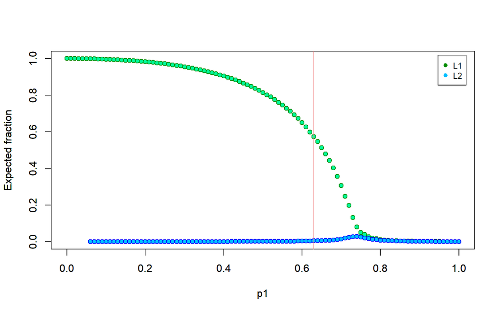

```r
plot(seq(0,1,by=0.01),EL1_list, xlab = "p1",ylab = "Expected fraction", ylim = c(0,1),
     pch=21, col="green4", bg="mediumspringgreen")
par(new=TRUE)
plot(seq(0,1,by=0.01),EL2_list,xlab = "p1",ylab = "Expected fraction",ylim = c(0,1),
     pch=21, col="blue", bg="deepskyblue")
abline(v=0.63, col="lightcoral")
legend("topright", inset=.02, c("L1","L2"), col=c("green4","deepskyblue"), pch=c(19,19), cex=0.8)
```

Si ens fixa’m només a la gràfica de L1, tenim que partir de $p_1=0.75$, aproximadament, no hi ha gaire diferència en el nombre esperat de nodes de les dues components majors del graf. Per tant, aquí ja no hi ha cap dubte de que la component connexa gegant ha desaparegut.

La teoria ens diu que, si $E(\mbox{deg}^2)>2E(\mbox{deg})$, el graf té una component connexa gegant i les altres components tenen ordre com a molt $log(10^4)\approx 9$, això és de l’ordre de $10^-3$ en termes relatius. Vegem fin quina $p_1$ es dóna la condició.

Sigui $P_d(k)$ la distribució dels graus, és a dir, la fracció de nodes de grau $k$, tenim que $P_d(1)=p_1$ i $P_d(3)=p_3=1-p_1$. A més, considerem $n_1$ el nombre de nodes de grau $1$ i $n_3$ el nombre de nodes de grau $3$. Així,
$$\begin{array}{rcllcl}
2E(\mbox{deg})&=& \displaystyle 2 \sum_{k} k\cdot P_d(k) &=& \displaystyle\ 2\left[ \sum_{k=1}^{n_1} 1p_1 + \sum_{k=1}^{n_3} 3(1-p_1) \right] = 2n_1p_1 + 6n_3(1-p_1),\\
E(\mbox{deg}^2)&=& \displaystyle 2 \sum_{k} k^2\cdot P_d(k) &=& \displaystyle 2\left[ \sum_{k=1}^{n_1} 1p_1 + \sum_{k=1}^{n_3} 9(1-p_1) \right] = n_1p_1 + 9n_3(1-p_1).
\end{array}$$

Ara, teim que $n_1=p_110^4$ i $n_3=10^4(1-p_1)$. Per tant,

$$\begin{array}{rcl}
2E(\mbox{deg})&=& \displaystyle 2\cdot10^4(p_1^2 + 3(1-p_1)^2),\\
E(\mbox{deg}^2)&=& 10^4(p_1^2 + 9(1-p_1)^2) \displaystyle .
\end{array}$$

Volem veure fins quin $p_1$ es satisfà $E(\mbox{deg}^2)>2E(\mbox{deg})$, equivalentment $E(\mbox{deg}^2)-2E(\mbox{deg})>0$. En termes de $p_1$ es

### Exercice 4

**4)** (**4 points**) *Stochastic models can be used to predict links in a network. Now, in a homework you were asked to produce an ERGM of Grey’s Anatomy sexual contact network. Using your model (or a friend’s, if you did not deliver this homework):*

Abans de respondre els apartats següents, recordem el model ERG emprat per les relacions de *Grey’s Anatomy*.

Primer, carregam les dades dels personatges de la sèrie i cream la xarxa amb els seus atributs, tal com es va fer al Handout 8.

```r
GA_nodes=read.table("GA_nodes.txt", header=TRUE)
GA_edges=read.table("GA_edges.txt")

#Cream graf.
GA=graph_from_data_frame(GA_edges, directed = FALSE)

#Afegim els atributs.
order=as.numeric(V(GA)$name)

V(GA)$label<-as.character(GA_nodes$name)[order]
V(GA)$name<- as.character(GA_nodes$name)[order]
V(GA)$sex<-as.character(GA_nodes$sex)[order]
V(GA)$birthyear<-GA_nodes$birthyear[order]
V(GA)$race<-as.character(GA_nodes$race)[order]
V(GA)$position<-as.character(GA_nodes$position)[order]
V(GA)$season<-GA_nodes$season[order]
V(GA)$sign<-as.character(GA_nodes$sign)[order]

#Ho pasam a tipus "network" per poder emprar ERGM.
GAnetwork=as.network(as.matrix(as_adjacency_matrix(GA)),directed=FALSE)
V(GA)$sex=as.factor(V(GA)$sex)
network::set.vertex.attribute(GAnetwork,"sex", V(GA)$sex)
network::set.vertex.attribute(GAnetwork,"birthyear", V(GA)$birthyear)
network::set.vertex.attribute(GAnetwork,"race", V(GA)$race)
network::set.vertex.attribute(GAnetwork,"position", V(GA)$position)
network::set.vertex.attribute(GAnetwork,"season", V(GA)$season)
network::set.vertex.attribute(GAnetwork,"sign", V(GA)$sign)
```

Cream el model amb les variables escollides.

```r
mod=ergm(GAnetwork ~ nodematch("sex") + degree(1) + absdiff("birthyear") +
          nodematch("race") + absdiff("season"))
summary(mod)
```

```
##
## ==========================
## Summary of model fit
## ==========================
##
## Formula:   GAnetwork ~ nodematch("sex") + degree(1) + absdiff("birthyear") +
##     nodematch("race") + absdiff("season")
##
## Iterations:  2 out of 20
##
## Monte Carlo MLE Results:
##                   Estimate Std. Error MCMC %  p-value
## nodematch.sex     -3.38801    0.70716      0  < 1e-04 ***
## degree1            2.22106    0.40733      0  < 1e-04 ***
## absdiff.birthyear -0.14629    0.02813      0  < 1e-04 ***
## nodematch.race     0.62686    0.27014      0 0.020527 *
## absdiff.season    -0.30475    0.08611      0 0.000421 ***
## ---
## Signif. codes:  0 '***' 0.001 '**' 0.01 '*' 0.05 '.' 0.1 ' ' 1
##
##      Null Deviance: 1311.4  on 946  degrees of freedom
##  Residual Deviance:  256.1  on 941  degrees of freedom
##
## AIC: 266.1    BIC: 290.4    (Smaller is better.)
```

- $\Delta(\mbox{nombre de relacions homosexuals})$ és la diferència en el nombre de relacions homosexuals en el graf abans i després d’afegir l’aresta. Així, resulta prendre el valor 1 si $i$ i $j$ són del mateix sexe, 0 altrament.
- $\Delta(\mbox{nombre de nodes de grau 1})$ resulta 1 si algun dels nodes $i$ o $j$ tenen grau 1 sense l’aresta $ij$, 2 si ambdós tenen grau 1 i 0 si cap dels dos en tenen.
- $\Delta(\mbox{suma diferències d'edat entre nodes adj.})$ és simplement la diferència d’edats entre $i$ i $j$.
- $\Delta(\mbox{nombre de relacions entre mateixa raça})$ resulta prendre el valor 1 si $i$ i $j$ són de la mateixa raça, 0 altrament.
- $\Delta(\mbox{suma diferències en el nombre de temporades})$ és la diferència entre el nombre de la temporada que apareix $i$ i $j$.

Ara, ja podem contestar les preguntes.

**(a)** *What is the link in the network with the highest probability (or the links, in the case of ties)? Look up somewhere on the Internet whether the corresponding contact appeared early or late in the series.*

Cercam els links amb una major probabilitat d’existir, és a dir, tals que $P(A_{ij}=1|G_{ij}^c)$ prengui el màxim valor possible. Aquest valor, es pren quan el log de odds d’aquesta probabilitat sigui màxim, per tant, vegem quan es dóna aquest màxim.

Donat que totes les variables del model prenen valors positiuso zero, ens interessa que aquelles que tenen coeficient negatiu en la estimació del log odds siguin zero. Així,

- $\Delta(\mbox{nombre de relacions homosexuals})=0,$ quan $i$ i $j$ siguin de diferent sexe.
- $\Delta(\mbox{suma diferències d'edat entre nodes adj.})=0$, quan $i$ i $j$ siguin de la mateix edat.
- $\Delta(\mbox{suma diferències en el nombre de temporades})=0$, quan $i$ i $j$ siguin de la mateixa temporada.

D’altra banda, les variables que tenen coeficient positiu ens interessa que prenguin el seu màxim valor.

- $\Delta(\mbox{nombre de nodes de grau 1})$. El màxim valor que pren és 2, quan $i$ i $j$ tenen grau 1.
- $\Delta(\mbox{nombre de relacions entre mateixa raça})$. El màxim valor és 1, quan $i$ i $j$ són de la mateixa raça.

Per tant, si existeix l’aresta en el graf, cercam una parella heterosexual de la mateixa raça, que només hagin tingut una relació (abans d’enllaçar-se), tinguin la mateixa edat i siguin de la mateixa temporada.

```r
V(GA)$sex<-as.character(GA_nodes$sex)[order]
for( male in which(V(GA)$sex=="M")){
  for( female in which(V(GA)$sex=="F")){

    if( (female %in% neighbors(GA,male)) & (V(GA)[male]$race==V(GA)[female]$race) &
        (degree(GA)[male]<= 2) & (degree(GA)[female]<=2)&
        (V(GA)[male]$birthyear==V(GA)[female]$birthyear)){
          cat(male,"-",female,":",V(GA)[male]$name,"and",V(GA)[female]$name,"\n")
    }
  }
}
```

No s’ha trobat ninguna aresa amb aquestes condicions, aleshores, anem a calcular la probabilitat de que existeixi l’aresta per cada aresta del graf.

Cream la funció que calcula el logarítme de odds, segons l’estimació lineal obtinguda.

```r
log_odds <- function(u,v, degree){
  coef=mod$coef
  coef['nodematch.sex']*(ifelse(V(GA)[u]$sex==V(GA)[u]$sex, 1, 0)) +
    coef['degree1']*(ifelse( (degree[u]==2 ) & (degree[u]==2) , 2, 0)) + #2 perque no contam l'aresta uv
    coef['degree1']*(ifelse( xor(degree[u]==2, degree[u]==2), 1, 0)) +
    coef['absdiff.birthyear']*abs( V(GA)[u]$birthyear-V(GA)[v]$birthyear ) +
    coef['nodematch.race']*(ifelse(V(GA)[u]$race==V(GA)[u]$race, 1, 0)) +
    coef['absdiff.season']*abs( V(GA)[u]$season-V(GA)[v]$season )
}
```

Ara, per a cada aresta, calculam la probabilitat de que existeixi emprant la funció anterior. Un cop tenim totes les probabilitats ens quedam amb el màxim i cercam les parelles amb aquesta probabilitat.

```r
degree=degree(GA)
edges=get.edgelist(GA)
log_odds_list=c()
for( i in 1:nrow(edges)){
  u=edges[i,1]
  v=edges[i,2]
  lo=log_odds(u,v,degree)
  log_odds_list=c(log_odds_list, exp(lo)/(1+exp(lo)) )
}
cat(" max:",max(log_odds_list),"\n", "row in edges:", which(log_odds_list==max(log_odds_list)))
```

```
##  max: 0.8226887
##  row in edges: 1 12
```

Així, les dues arestes amb una major probabilitat d’existir són

```r
cat("", edges[1,],"\n",edges[12,])
```

```
##  derek addison
##  kepner avery
```

Segons la informació del personatge Addison que podem trobar [aquí](http://greys.wikia.com/wiki/Addison_Montgomery), Derek i Addison són parella ja abans de la primera temporada. A més, [aquí](https://en.wikipedia.org/wiki/April_Kepner) trobam que Kepner i Avery comencen una relació a la temporada 8 i, de fet, Keprel no té cap relació sexual abans de juntar-se amb kepner.

**(b)** *What is the most probable new (that is, absent from the network) sexual contact between a pair of characters in that network? Look up somewhere on the Internet whether this contact has occurred in the series after season 8, and (if the answer is positive) when.*

Ara, si no existeix l’aresta en el graf, cercam una parella heterosexual de la mateixa raça, que només hagin tingut una relació (abans d’enllaçar-se), tinguin la mateixa edat i siguin de la mateixa temporada. Vegem si en aquest cas sí trobam la parella.

```r
V(GA)$sex<-as.character(GA_nodes$sex)[order]
for( male in which(V(GA)$sex=="M")){
  for( female in which(V(GA)$sex=="F")){

    if( !(female %in% neighbors(GA,male)) & (V(GA)[male]$race==V(GA)[female]$race) &
        (degree(GA)[male]==1) & (degree(GA)[female]==1)&
        (V(GA)[male]$birthyear==V(GA)[female]$birthyear)){
          cat(male,"-",female,":",V(GA)[male]$name,"and",V(GA)[female]$name,"\n")
        }
  }
}
```

```
## 7 - 41 : perkins and nancy
## 39 - 31 : hank and ava
```

Tenim dues parelles amb una altra probabilitat d’emparellar-se, la probabilitat és concretament

```r
coef=mod$coef
cat("Probability:", exp(coef['degree1']*2+coef['nodematch.race'])/(1+exp(coef['degree1']*2+coef['nodematch.race'])))
```

```
## Probability: 0.9937504
```

Sembla que Perkins i Nancy no estableixen cap relació, encara que Perkins no ha tornat a apareixer de de la temporada 7; veure [aquí](http://greysanatomy.wikia.com/wiki/Andrew_Perkins). D’altra banda, Hank i Ava tampoc tenen cap relació romàntica, fet comprensible ja que Hank només surt en un episodi de la temporada 1, tal com diu [aquí](http://greysanatomy.wikia.com/wiki/Hank).